# **Final Exam**: Statistical Methods for Small Sample Sizes

Name, Study Program and Matriculation Number** : Baptiste ROIZARD, Bioinformatics MSc., 5594490

## Exercise 1

A team of researchers aims to investigate whether geographic factors affect consumer satisfaction of a novel social media platform. They herewith want to compare the satisfaction of users from urban and rural environments. They consult you to help them setting up the survey.

1. You discuss potential endpoints with the team in a first meeting. The first possible endpoint is asking users whether they are very happy, happy, medium, acceptable or unhappy (Option A), or using the daily time (in minutes) users actively used the app (Option B) as an endpoint. Discuss the differences between the endpoints from statistical point of views.

**Answer**:

- **Option A (Categorical Endpoint):** The response variable is ordinal, with categories: very happy, happy, medium, acceptable, and unhappy. This type of data is analyzed using non-parametric tests like the Wilcoxon-Mann-Whitney test or the Brunner-Munzel test. It provides insights into the distribution of satisfaction levels but does not provide a direct measure of magnitude. There is also potential for subjective bias as users may interpret satisfaction levels differently.
- **Option B (Continuous Endpoint):** The response variable is continuous, representing the daily time (in minutes) spent on the app. This can be analyzed using t-tests (assuming normality) or alternatives like the Wilcoxon rank-sum test if normality is not assumed. It provides more precise and quantifiable data, enabling more powerful statistical tests and clearer interpretation of effect sizes. However, app usage time might not fully capture user satisfaction, as users might spend more time due to addiction or lack of alternatives.
2. Formulate possible statistical models for each endpoint, define the treatment effects and interpret the model parameters.

**Answer**:

**Possible Statistical Models:**

- **For Option A:**
  - **Test: Wilcoxon-Mann-Whitney test**
    - **Hypotheses:**
      - Null hypothesis: The distributions of satisfaction levels are identical between urban and rural users.
      - Alternative hypothesis: The distributions are different.
    - **Assumptions:** The test assumes that the two samples are independent and that the variable is ordinal.
  - **Test: Brunner-Munzel test**
    - **Hypotheses:**
      - Null hypothesis: The probability that a randomly chosen observation from one group is greater than a randomly chosen observation from the other group is 0.5.
      - Alternative hypothesis: This probability differs from 0.5.
    - **Assumptions:** Does not assume equal variances or similar distribution shapes, making it more flexible than the Wilcoxon-Mann-Whitney test.
- **For Option B:**
  - **Test: t-test**
    - **Hypotheses:**
      - Null hypothesis: The mean daily usage time is equal between urban and rural users.
      - Alternative hypothesis: The mean daily usage time differs between the two groups.
    - **Assumptions:**
      - The data are continuous.
      - The samples are independent.
      - The data follow a normal distribution (for the standard t-test) or use a Welch’s t-test if variances are unequal.
  - **Test: Wilcoxon rank-sum test**
    - **Hypotheses:**
      - Null hypothesis: The distributions of daily usage time are identical between urban and rural users.
      - Alternative hypothesis: The distributions are different.
    - **Assumptions:** The test assumes independent samples and that the data are continuous or ordinal.
3. Which of the two endpoints would you prefer? State your conclusion in 1 - 2 sentences.

**Answer**:

I would prefer **Option A (Categorical Endpoint)** as it directly measures user satisfaction, which is the primary interest of the study, whereas usage time might not accurately reflect satisfaction.

## Exercise 2

In an animal testing experiment, researchers measure the body weight from rats in a control and an active treatment group:

```r
        control = c(163.1, 174.2, 150.2, 183.4, 184.2, 166.6, 176.9, 174.7, 151.2, 174.9)
        treat   = c(159.8, 154.9, 158.8, 171.1, 148.8, 164, 167.5, 161.6, 159.5, 143.0)
```

1. The team of researchers discuss different options to model the data with a statistical model. Write down a parametric and a nonparametric model to model the data. Explain the key differences between the two options.

**Answer**:

**Parametric model:**  
A parametric model assumes that the data follow a specific probability distribution characterized by certain parameters (e.g., mean and variance).  
- In this case, we can use a **two-sample t-test** to compare the body weights in the control and treatment groups.  
- This test assumes that the data are normally distributed and that the variances of the two groups are equal.  
- The null hypothesis ($H_0$) is that the population means of the two groups are equal.

**Nonparametric model:**  
A nonparametric model does not make assumptions about the data’s distribution.  
- We can use the **Wilcoxon-Mann-Whitney test** to compare the distributions of body weights without assuming normality.  
- This test uses the ranks of the data rather than the raw values to test if one distribution tends to have higher values than the other.

Parametric models rely on distributional assumptions and are generally more powerful when these assumptions are met. Nonparametric models are more flexible and robust when assumptions (e.g., normality) are violated but may have less power if the assumptions of the parametric model are correct.

2. Summarize the data descriptively: Compute the means, medians, standard deviations and 95% confidence intervals (for the means) for each group. In addition, plot the data appropriately and interpret the result in 1 - 2 sentences.

**Answer**:

A boxplot is a good choice to visualize differences in central tendency and variability between the groups.

```r
# Data
control <- c(163.1, 174.2, 150.2, 183.4, 184.2, 166.6, 176.9, 174.7, 151.2, 174.9)
treat   <- c(159.8, 154.9, 158.8, 171.1, 148.8, 164, 167.5, 161.6, 159.5, 143.0)

# Descriptive statistics
control_mean <- mean(control)
control_median <- median(control)
control_sd <- sd(control)
control_ci <- t.test(control)$conf.int

treat_mean <- mean(treat)
treat_median <- median(treat)
treat_sd <- sd(treat)
treat_ci <- t.test(treat)$conf.int

# Print results
cat("Control group: Mean =", control_mean, "Median =", control_median, "SD =", control_sd,
    "95% CI =", control_ci, "\n")
```

```
## Control group: Mean = 169.94 Median = 174.45 SD = 12.00539 95% CI = 161.3519 178.5281
```

```r
cat("Treatment group: Mean =", treat_mean, "Median =", treat_median, "SD =", treat_sd,
    "95% CI =", treat_ci, "\n")
```

```
## Treatment group: Mean = 158.9 Median = 159.65 SD = 8.353974 95% CI = 152.9239 164.8761
```

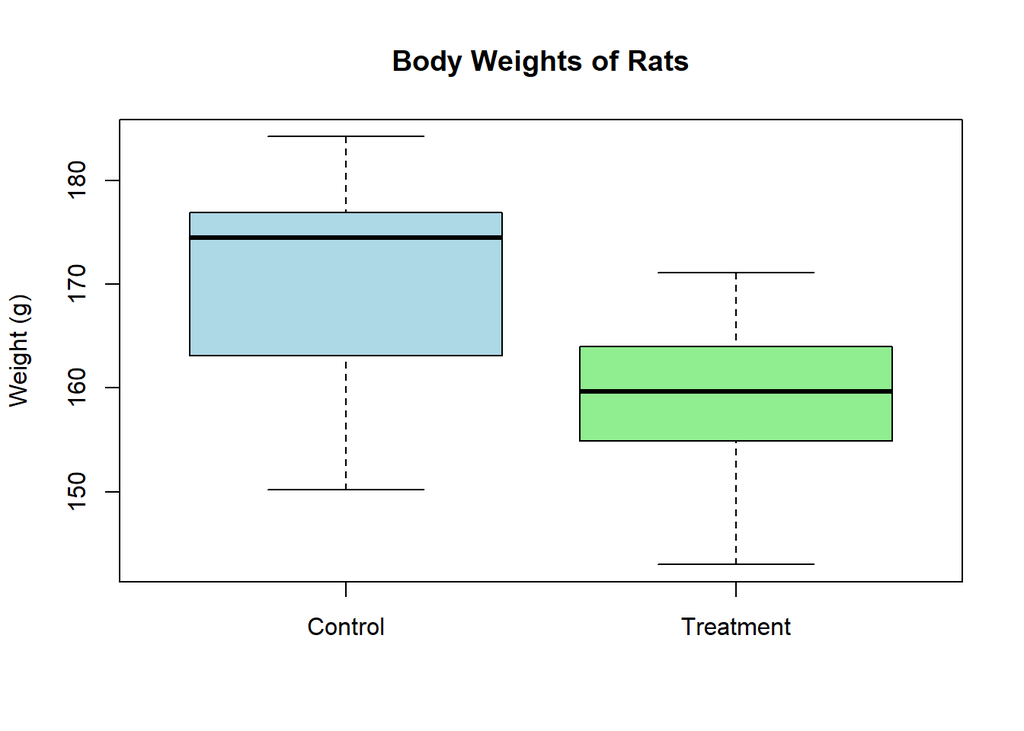

```r
boxplot(control, treat, names = c("Control", "Treatment"),
        main = "Body Weights of Rats", ylab = "Weight (g)", col = c("lightblue", "lightgreen"))
```

Here, there seems to be a significant difference in the means of the two groups and the medians (as the boxplot shows) indicate that the data in the control group does not seem to follow a normal distribution (since it is not symmetrical). In that case, it makes more sense to use a nonparametric model (no assumption of normality).

3. The team wonders about how to describe differences between the two distributions.
1. Explain the nonparametric relative effect for two independent samples in words (1 - 2 sentences).

**Answer**:

The **relative effect** is a nonparametric measure that compares the distribution of two independent samples.  
- It is defined as the probability that a randomly chosen observation from one distribution is greater than a randomly chosen observation from the other distribution.  
- A relative effect of 0.5 indicates that the two distributions are similar; values greater than 0.5 suggest that observations from the first sample tend to be larger.

2. Estimate the relative effect of the two samples and interpret the result in 1 - 2 sentences.

**Answer**:

```r
library(WRS2)  # for relative effect calculation
rel_effect <- wilcox.test(control, treat)$statistic / (length(control) * length(treat))
cat("Estimated relative effect:", rel_effect, "\n")
```

```
## Estimated relative effect: 0.79
```

We get an estimated relative effect value of 0.79 which is far from 0.5 and thus indicate a shift in the distributions. Had this effect been closer to 0.5, we would have concluded that the two distributions are similar.

3. Test the null hypothesis of the equality of the two distributions with the exact Wilcoxon-Mann-Whitney test: Report the value of the test statistic and the two-sided p-value. Would you reject the null hypothesis at $5\%$ level of significance?

**Answer**:

```r
# Wilcoxon-Mann-Whitney test
wmw_test <- wilcox.test(control, treat, exact = TRUE) # by default it is two-sided
cat("Wilcoxon test statistic:", wmw_test$statistic, "p-value:", wmw_test$p.value, "\n")
```

```
## Wilcoxon test statistic: 79 p-value: 0.02880556
```

Since $p < 0.05$, we have enough evidence to reject $H_0$ and conclude that the distributions differ significantly.

4. Explain the exact Wilcoxon-Mann-Whitney test in 1 - 2 sentences.

**Answer**:

The **exact Wilcoxon-Mann-Whitney test** compares two independent samples to assess whether one tends to have larger values than the other. It ranks the pooled data and compares the sum of the ranks for each group. The test does not assume normality and is appropriate for small sample sizes.

5. As an example, suppose the data of the two groups given by $A=\{3,5,6\}$ and $B = \{2,4\}$. Compute the test statistic of the exact Wilcoxon-rank test, the exact null distribution of the test statistic, and the two-sided p-value. UPDATE: Please compute the recursion for one single case (to receive a sum of 6). You don’t need to compute the whole distribution and related statistics.

**Answer**:

The exact Wilcoxon-rank test involves ranking the combined data and summing the ranks of the observations from the second group (Group B in this case).

We combine the data from both groups:
$$\{2, 3, 4, 5, 6\}$$

We assign ranks to the values in ascending order:  
- 2 → Rank 1  
- 3 → Rank 2  
- 4 → Rank 3  
- 5 → Rank 4  
- 6 → Rank 5

**Recursion to Compute a Sum of 6**  
To compute the probability of obtaining a sum of ranks equal to 6, we consider all possible ways to assign two ranks to Group B that sum to 6.

From the available ranks $\{1, 2, 3, 4, 5\}$, the possible rank pairs that sum to 6 are: - $(1,5)$ - $(2,4)$

Since each possible selection of two ranks occurs with equal probability, we can determine the probability of obtaining a sum of 6.

The total number of ways to choose 2 ranks from 5 is:

$$\binom{5}{2} = 10$$

Since two of these choices lead to a sum of 6, the probability is:

$$\frac{2}{10} = 0.2$$

**NB:**
The recursive formula
$$h(s, m, N) = h(s, m, N-1) + h(s - N, m - 1, N - 1)$$
yields the same result. Applying it for $h(6,2,5)$ confirms that the number of valid subsets summing to 6 is **2**, which matches our direct enumeration.

## Exercise 3

A researcher is studying the effect of a new cognitive training program on reaction times. Ten participants complete a reaction time test before and after undergoing the training.

1. Model the data nonparametrically and explain the model components in 1 - 2 sentences.

**Answer**:

A nonparametric model for this paired data uses the sign test, which compares the number of positive and negative differences between before and after training reaction times without assuming a specific distribution. Each pair $(X_{1k}, X_{2k})$ is treated independently, and the sign of the difference $D_k = X_{1k} - X_{2k}$ is the primary focus rather than the magnitude.

2. A team member suggests to use the sign effect $\theta = P(X_{11} < X_{21}) + \tfrac12 P(X_{11} = X_{21})$ as treatment effect, and the team wonders about its interpretation. Compute the sign effect $\theta$ under the assumption that the pairs follow a bivariate normal distribution,
   $$\mathbf{Z}_k = (X_{1k}, X_{2k})' \sim \mathcal{N} \left(
   \mathbf{\mu}, \mathbf{\Sigma} \right)$$
   where $\mathbf{\mu} = (\mu_X, \mu_Y)$ and
   $$\mathbf{\Sigma} = \begin{bmatrix} \sigma_X^2 & \rho \sigma_X
   \sigma_Y \\ \rho \sigma_X \sigma_Y & \sigma_Y^2 \end{bmatrix}.$$
   Derive an expression for $\theta$ in terms of the standard normal cumulative distribution function $\Phi(\cdot)$ and explain the result in 1 - 2 sentences.

**Answer**:

Given:
$$\mathbf{Z}_k = (X_{1k}, X_{2k})' \sim \mathcal{N} \left(
\mathbf{\mu}, \mathbf{\Sigma} \right)$$
where $\mathbf{\mu} = (\mu_X, \mu_Y)$ and
$$\mathbf{\Sigma} = \begin{bmatrix} \sigma_X^2 & \rho \sigma_X
\sigma_Y \\ \rho \sigma_X \sigma_Y & \sigma_Y^2 \end{bmatrix}.$$

We are interested in:
$$\theta = P(X_1 < X_2) + \frac{1}{2} P(X_1 = X_2).$$

Since we’re working with continuous data, $P(X_1 = X_2) = 0$ under a continuous distribution. So,
$$\theta = P(X_1 < X_2).$$

Consider the difference $D = X_1 - X_2$. If $(X_1, X_2)$ follows a bivariate normal distribution, then $D$ also follows a normal distribution with:
$$\mu_D = \mu_X - \mu_Y, \quad \sigma_D^2 = \sigma_X^2 + \sigma_Y^2 - 2
\rho \sigma_X \sigma_Y.$$

Thus:
$$\theta = P(D < 0) = \Phi \left( \frac{0 - \mu_D}{\sigma_D} \right) =
\Phi \left( \frac{\mu_Y - \mu_X}{\sqrt{\sigma_X^2 + \sigma_Y^2 - 2 \rho
\sigma_X \sigma_Y}} \right),$$
where $\Phi(\cdot)$ is the standard normal cumulative distribution function.

3. Since the sample size is rather small, the team wonders about the quality of asymptotic sign test, and whether the test controls the type-1 error rate of $\alpha = 5\%$ (two-sided) accurately in their situation. Conduct a type-1 error simulation of the asymptotic sign-test with $n_{sim} = 10,000$ simulation runs in three different situations assuming the data follow a bivariate normal distributions with equal variances $\sigma_X^2= \sigma_Y^2 = 1$ and correlations $\rho \in \{0,0.5,0.95\}$. Please implement the value of the test statistic and do not use an implemented version of the test of any software package. Interpret the outcome of the simulation study in 1 - 2 sentences. Would you recommend using the test?

**Answer**:

**Steps for this question:**  
1. Simulate data from a bivariate normal distribution with specified correlation $\rho$.  
2. Calculate the sign test statistic manually (counting how many differences are positive).  
3. Compare the test statistic against the critical bounds for a binomial distribution with $n = 10$ and $p = 0.5$.  
4. Run 10,000 simulations for $\rho = 0, 0.5, 0.95$.  
5. Interpret the results.

```r
simulate_sign_test_type1 <- function(n_sim, n_pairs, alpha = 0.05, rho_values) {
  set.seed(123)

  # Initialize results
  error_rates <- numeric(length(rho_values))

  # Critical values for binomial test (two-sided, alpha = 0.05)
  critical_lower <- qbinom(alpha/2, n_pairs, 0.5)
  critical_upper <- qbinom(1 - alpha/2, n_pairs, 0.5)

  for (i in seq_along(rho_values)) {
    rho <- rho_values[i]
    rejections <- 0

    # Generate covariance matrix
    sigma <- matrix(c(1, rho, rho, 1), 2, 2)

    for (sim in 1:n_sim) {
      # Simulate paired observations
      samples <- MASS::mvrnorm(n_pairs, mu = c(0, 0), Sigma = sigma)

      # Calculate sign test statistic: count positive differences
      diff_signs <- sum(samples[, 1] > samples[, 2])

      # Check if test statistic is in rejection region
      if (diff_signs <= critical_lower || diff_signs >= critical_upper) {
        rejections <- rejections + 1
      }
    }

    # Calculate empirical type-1 error rate
    error_rates[i] <- rejections / n_sim
  }

  # Return results
  names(error_rates) <- paste0("rho_", rho_values)
  return(error_rates)
}

# Run the simulation
rho_values <- c(0, 0.5, 0.95)
type1_errors <- simulate_sign_test_type1(n_sim = 10000, n_pairs = 10, rho_values = rho_values)
type1_errors
```

```
##    rho_0  rho_0.5 rho_0.95
##   0.1049   0.1153   0.1101
```

The observed type-1 error rates are consistently above the nominal significance level of $\alpha = 0.05$. This suggests that the asymptotic sign test does not accurately control the type-1 error rate when sample sizes are small, regardless of the correlation between the variables.

I would not recommend using the asymptotic sign test in this setting due to its poor type-1 error control, especially when sample sizes are limited. Alternative methods or exact tests may provide more reliable results.

**Why Compare to a Binomial Distribution?**  
The asymptotic sign test assumes that, under $H_0$, each pair has a 50% chance of showing a positive difference, making the number of positive signs follow a **Binomial(10, 0.5)** distribution. The rejection region is determined by the 2.5% and 97.5% quantiles of this binomial distribution.

**Answer**:

The R function `wilcoxon_exact` below implements the exact Wilcoxon signed-rank test by enumerating all possible sign permutations, returning the test statistic $W$, the two-sided p-value, and the estimated sign effect.

```r
wilcoxon_exact <- function(x, y) {
  # Step 1: Compute differences
  d <- x - y
  d <- d[d != 0]  # Remove zeros

  # Step 2: Rank absolute differences
  ranks <- rank(abs(d))

  # Step 3: Compute the observed test statistic
  W_obs <- sum(ranks[d > 0])

  # Generate all permutations of signs
  n <- length(d)
  all_signs <- expand.grid(rep(list(c(-1, 1)), n))

  # Compute all possible W values
  W_all <- apply(all_signs, 1, function(s) sum(ranks * s))

  # Compute p-value (two-sided)
  p_value <- mean(abs(W_all) >= abs(W_obs))

  # Estimate sign effect
  sign_effect <- mean(W_all > 0)

  return(list(W = W_obs, p_value = p_value, sign_effect = sign_effect))
}
```

5. Finally, the data are

```r
before_training <- c(550, 470, 530, 610, 590, 510, 580, 495, 650, 575)
after_training <- c(520, 450, 510, 590, 570, 490, 560, 475, 620, 550)

# Combine the data into a data frame
reaction_time_data <- data.frame(
  Participant = 1:10,
  Before_Training = before_training,
  After_Training = after_training
)
reaction_time_data
```

```
##    Participant Before_Training After_Training
## 1            1             550            520
## 2            2             470            450
## 3            3             530            510
## 4            4             610            590
## 5            5             590            570
## 6            6             510            490
## 7            7             580            560
## 8            8             495            475
## 9            9             650            620
## 10          10             575            550
```

Analyze the data set with the exact Wilcoxon signed-rank test implemented above. The analysis should include

- descriptive summary of the data with means, medians, standard deviations, 95% confidence intervals (for the means)
- graphical representation (boxplot and line plot)
- Estimator of the sign effect
- Test results

**Answer**:

```r
## Descriptive summary of the data
before_training <- c(550, 470, 530, 610, 590, 510, 580, 495, 650, 575)
after_training <- c(520, 450, 510, 590, 570, 490, 560, 475, 620, 550)

# Summary statistics
summary_data <- data.frame(
  Statistic = c("Mean", "Median", "SD", "95% CI Lower", "95% CI Upper"),
  Before = c(mean(before_training), median(before_training), sd(before_training),
             mean(before_training) - qt(0.975, length(before_training)-1)*sd(before_training)/sqrt(length(before_training)),
             mean(before_training) + qt(0.975, length(before_training)-1)*sd(before_training)/sqrt(length(before_training))),
  After = c(mean(after_training), median(after_training), sd(after_training),
            mean(after_training) - qt(0.975, length(after_training)-1)*sd(after_training)/sqrt(length(after_training)),
            mean(after_training) + qt(0.975, length(after_training)-1)*sd(after_training)/sqrt(length(after_training)))
)
summary_data
```

```
##      Statistic    Before     After
## 1         Mean 556.00000 533.50000
## 2       Median 562.50000 535.00000
## 3           SD  55.56778  53.75097
## 4 95% CI Lower 516.24921 495.04887
## 5 95% CI Upper 595.75079 571.95113
```

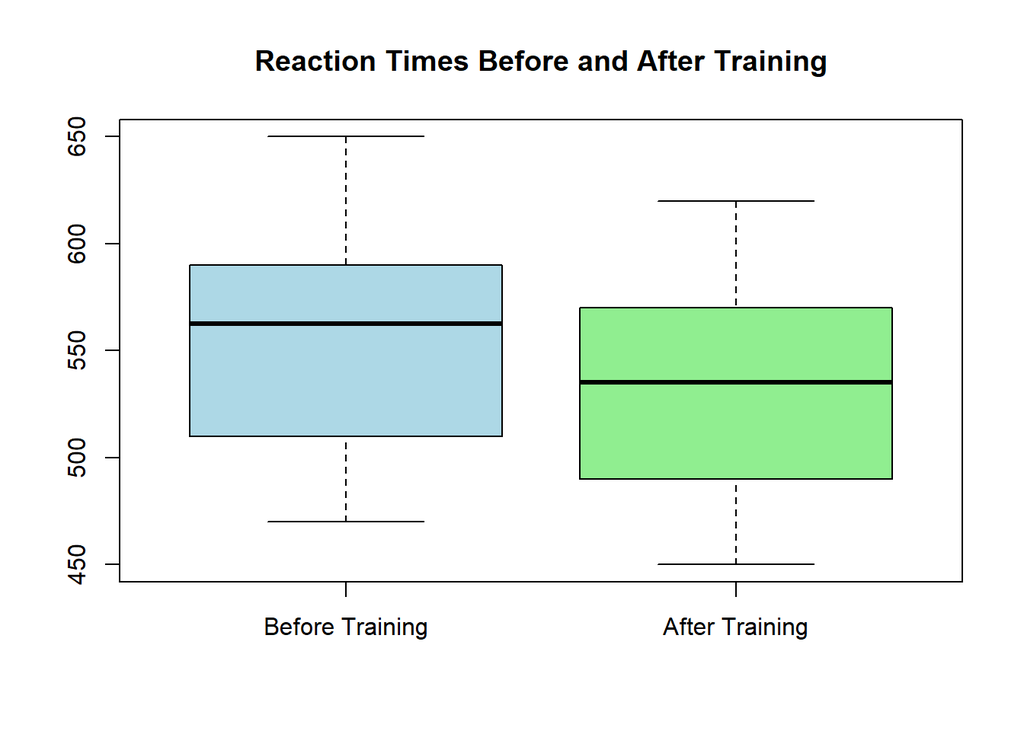

```r
## Graphical representation (boxplot and line plot)
# Boxplot
boxplot(before_training, after_training, names=c("Before Training", "After Training"),
        main="Reaction Times Before and After Training", col=c("lightblue", "lightgreen"))
```

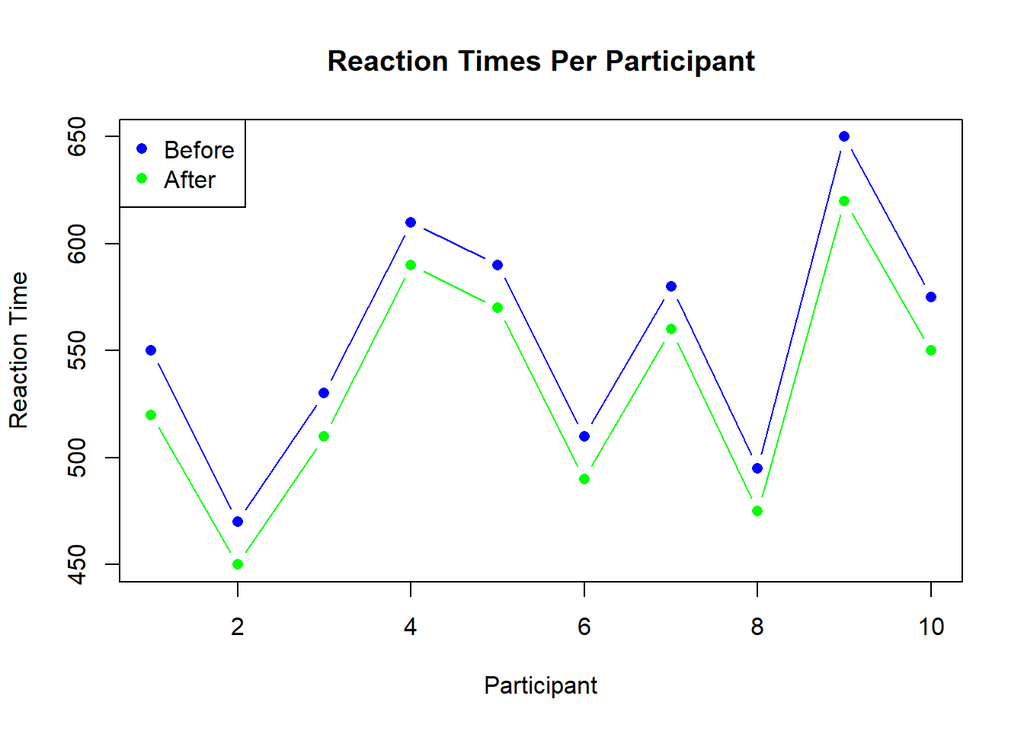

```r
# Line plot
plot(1:10, before_training, type="b", col="blue", pch=16, ylim=range(c(before_training, after_training)),
     xlab="Participant", ylab="Reaction Time", main="Reaction Times Per Participant")
lines(1:10, after_training, type="b", col="green", pch=16)
legend("topleft", legend=c("Before", "After"), col=c("blue", "green"), pch=16)
```

```r
## Wilcoxon signed-rank test results
result <- wilcoxon_exact(before_training, after_training)
result
```

```
## $W
## [1] 55
##
## $p_value
## [1] 0.001953125
##
## $sign_effect
## [1] 0.5
```

## Exercise 4

A hospital is conducting a study to evaluate the effectiveness of five different rehabilitation programs for patients recovering from knee surgery. Due to strict inclusion criteria, only a small number of patients can be enrolled in the study. Each patient is randomly assigned to one of the five treatment groups, which differ in exercise intensity, frequency, and supplementary therapies (e.g., hydrotherapy, electrotherapy, or manual therapy). As the primary outcome, the team decides for a functional mobility score that is measured on each patient after 6 weeks. Since the sample sizes are rather small, the team of the data. The data are provided in

```r
group <- c(rep("A",11), rep("B",16),rep("C",16), rep("D",19),rep("E", 16))
reduction <- c(8.88,9.54, 13.12, 10.14, 10.26, 13.43, 10.92,  7.47,  8.63,  9.11, 12.45, 11.41,
13.79, 13.76, 11.07, 13.56, 11.83, 12.51, 11.94, 11.91, 14.74, 11.55, 15.03,  8.90,
13.17,12.25, 12.43,  8.76,  6.58,  6.62,  7.43,  5.56 , 8.36,  7.72 , 8.01,  8.77,
 7.26,  9.29,  7.56,  8.66,  8.87,  7.35, 10.30, 14.99, 14.10, 13.48, 11.74, 15.72,
11.80, 17.37, 16.07, 12.53, 10.95, 11.58, 13.51, 11.43,  9.66, 12.24, 14.84, 11.85,
13.21, 11.72,  7.24,  5.11,  6.02,  6.49, 10.69,  5.70,  7.47,  7.16,  5.08,  5.86,
4.89,  4.90,  4.48, 12.82,  4.20,  2.43)
data<-data.frame(group=factor(group),reduction=reduction)
```

1. Summarize the data descriptively: Estimate the means, variances and 95% confidence intervals (for the means) for each treatment group. In addition, display the data graphically. Explain and interpret the results in 1 - 2 sentences.

**Answer**:

```r
# Load necessary libraries
library(dplyr)
library(ggplot2)

# Calculate mean, variance, and 95% CI for each group
summary_stats <- data %>%
  group_by(group) %>%
  summarise(
    mean = mean(reduction),
    variance = var(reduction),
    n = n(),
    se = sd(reduction) / sqrt(n),
    lower_ci = mean - qt(0.975, df = n - 1) * se,
    upper_ci = mean + qt(0.975, df = n - 1) * se
  )

# Print summary statistics
print(summary_stats)
```

```
## # A tibble: 5 × 7
##   group  mean variance     n    se lower_ci upper_ci
##   <fct> <dbl>    <dbl> <int> <dbl>    <dbl>    <dbl>
## 1 A     10.4      3.76    11 0.584     9.06    11.7
## 2 B     12.5      2.30    16 0.379    11.7     13.3
## 3 C      7.94     1.39    16 0.295     7.32     8.57
## 4 D     13.1      3.97    19 0.457    12.1     14.1
## 5 E      6.28     6.33    16 0.629     4.94     7.62
```

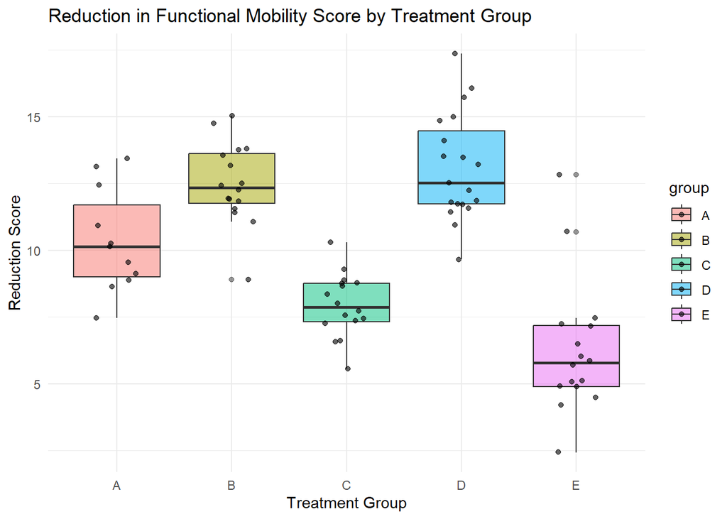

```r
# Create a boxplot to visualize the data
ggplot(data, aes(x = group, y = reduction, fill = group)) +
  geom_boxplot(alpha = 0.5) +
  geom_jitter(position = position_jitter(0.2), alpha = 0.6) +
  theme_minimal() +
  labs(title = "Reduction in Functional Mobility Score by Treatment Group",
       x = "Treatment Group",
       y = "Reduction Score")
```

The descriptive statistics indicate differences in mean reduction scores across the five treatment groups. The boxplot reveals variations in score distributions, suggesting potential differences in treatment effectiveness that warrant further statistical testing.

2. The researcher wonder how the data can be translated into a statistical model to define the treatment effects to model the impact of the treatment on the response. Write down the statistical model and the (relative) treatment effects and explain them in 1 - 2 sentences. Did you decide for the weighted or the unweighted version? In addition, formulate the null and alternative hypothesis.

**Answer**:

We model the treatment effects using a simple linear model for nonparametric analysis.

$$Y_{ij} = \mu + \tau_i + \epsilon_{ij}$$

Where:  
- $Y_{ij}$: Reduction score for the $j$-th patient in the $i$-th group  
- $\mu$: Overall mean reduction score  
- $\tau_i$: Treatment effect for group $i$  
- $\epsilon_{ij}$: Random error term

The treatment effect for each group is the difference between the group’s mean and the overall mean:

$$\tau_i = \mu_i - \mu$$

- **Null Hypothesis (H₀)**: All treatment groups have the same effect on the mobility score.
  $$H_0: \tau_1 = \tau_2 = \tau_3 = \tau_4 = \tau_5 = 0$$
- **Alternative Hypothesis (H₁)**: At least one treatment group differs from the others.
  $$H_1: \exists i \neq j \text{ such that } \tau_i \neq \tau_j$$

We use a linear model to capture potential treatment effects. If the Kruskal-Wallis test indicates a significant difference, we will investigate further with multiple contrast tests to identify which treatments differ significantly.

3. Estimate the treatment effects formulated above and interpret the outcome.

**Answer**:

1. **Calculate the Overall Mean**:  
   Compute the overall mean reduction score across all groups.
2. **Calculate Treatment Effects**:
   For each group $i$, subtract the overall mean from the group mean:
   $$\tau_i = \mu_i - \mu$$
   where $\mu_i$ is the mean for group $i$ and $\mu$ is the overall mean.

```r
# Calculate the overall mean
overall_mean <- mean(data$reduction)

# Calculate treatment effects for each group
treatment_effects <- summary_stats %>%
  mutate(treatment_effect = mean - overall_mean)

# Print the results
print(treatment_effects)
```

```
## # A tibble: 5 × 8
##   group  mean variance     n    se lower_ci upper_ci treatment_effect
##   <fct> <dbl>    <dbl> <int> <dbl>    <dbl>    <dbl>            <dbl>
## 1 A     10.4      3.76    11 0.584     9.06    11.7             0.228
## 2 B     12.5      2.30    16 0.379    11.7     13.3             2.36
## 3 C      7.94     1.39    16 0.295     7.32     8.57           -2.19
## 4 D     13.1      3.97    19 0.457    12.1     14.1             2.96
## 5 E      6.28     6.33    16 0.629     4.94     7.62           -3.85
```

The treatment effects indicate how each group’s mean reduction score differs from the overall mean. Positive values suggest better-than-average performance (greater reduction in mobility scores), while negative values suggest worse performance.

3. Test the null hypothesis formulated above with the Kruskal-Wallis test. Would you reject the null hypothesis at 5% level of significance?

**Answer**:

The Kruskal-Wallis test is a nonparametric method to test whether the distributions of the reduction scores differ across the five treatment groups. The Kruskal-Wallis test ranks the data and tests whether the group medians differ.

```r
# Conduct the Kruskal-Wallis test
kruskal_test <- kruskal.test(reduction ~ group, data = data)

# Print test result
print(kruskal_test)
```

```
##
##  Kruskal-Wallis rank sum test
##
## data:  reduction by group
## Kruskal-Wallis chi-squared = 53.095, df = 4, p-value = 8.14e-11
```

Since the p-value is less than 0.05, we have sufficient evidence to reject $H_0$: there is sufficient evidence to conclude that at least one treatment group differs from the others.

4. A researcher recommends using a multiple contrast test instead. He says: ``Well, we are interested in seeing the differences from the B to E to treatment A only, but knew beforehand that treatment B and D will be somewhat similar’’. Can you help them conducting a proper multiple contrast test? Write the contrast matrix of interest and conduct the test. Explain and interpret the result in 1 - 2 sentences.

**Answer**:

```r
# Load necessary package
library(multcomp)
# Fit a nonparametric model (rank-based)
data$reduction_rank <- rank(data$reduction)
model <- aov(reduction_rank ~ group, data = data)

# Define the contrast matrix
contrast_matrix <- rbind(
  "B vs A" = c(-1, 1, 0, 0, 0),
  "C vs A" = c(-1, 0, 1, 0, 0),
  "D vs A" = c(-1, 0, 0, 1, 0),
  "E vs A" = c(-1, 0, 0, 0, 1),
  "B vs D" = c(0, 1, 0, -1, 0)
)

# Apply the multiple contrast test
mct <- glht(model, linfct = mcp(group = contrast_matrix))

# Print results
summary(mct)
```

```
##
##   Simultaneous Tests for General Linear Hypotheses
##
## Multiple Comparisons of Means: User-defined Contrasts
##
##
## Fit: aov(formula = reduction_rank ~ group, data = data)
##
## Linear Hypotheses:
##             Estimate Std. Error t value Pr(>|t|)
## B vs A == 0   16.409      5.079   3.231  0.00820 **
## C vs A == 0  -17.466      5.079  -3.439  0.00452 **
## D vs A == 0   18.883      4.913   3.844  0.00113 **
## E vs A == 0  -26.685      5.079  -5.254  < 0.001 ***
## B vs D == 0   -2.474      4.400  -0.562  0.95166
## ---
## Signif. codes:  0 '***' 0.001 '**' 0.01 '*' 0.05 '.' 0.1 ' ' 1
## (Adjusted p values reported -- single-step method)
```

5. The comparison of multiple samples occurs frequently in statistical practice. Does it make sense to test the global null hypothesis with a Kruskal-Wallis test first and, if the null hypothesis is rejected, using multiple contrast tests (or multiple comparison procedure) as post-hoc tests consecutively? Explain your conclusion in 1 - 2 sentences.

**Answer**:

Yes, it makes sense to perform a Kruskal-Wallis test first, as it determines whether any group differences exist. If the null hypothesis is not rejected, further multiple contrast tests are unnecessary. This approach reduces the number of comparisons, helping to control the family-wise error rate and saving time and computational effort.